# Hypothesis Testing

Day 14

Claire Kelling

Carleton College  
STAT 120 - Fall 2026

## Question of the Day

In your group, who has the most cousins?

## Today’s Topics

Housekeeping:

- Quiz 2 Friday! Half of class. Questions?
- Midterm Evaluation due at 11:59pm on Friday!
  - Extra Credit available
- (No “Day 13” Notes)

Topics covered today:

- Bootstrapping Review
- Introduce Hypothesis Testing

# Hypothesis Testing

## Extrasensory Perception

- **ESP**: the ability to perceive things by means other than the known senses
- One way to test for ESP is with Zener cards:

[figure not shown]

- Subjects draw a card at random and telepathically communicate this to someone who then guesses the symbol

## Extrasensory Perception, try it!

**Example**

- Randomly choose a letter from A B C D E and write it down (don’t show anyone!)
- Find a partner, telepathically communicate your letter (no auditory or visual clues!) and have them guess your letter. Do it five times, then switch roles.
- How many times did you guess correctly? Let’s do it!

Suppose you did this 5 times and guessed correctly 2 times. Is this evidence that you have ESP abilities?

## Extrasensory Perception

- There are five cards with five different symbols
- **If there is no such thing as ESP**, what proportion (p) of guesses should be correct?
1. p = 0
2. p = 1/4
3. p = 1/5
4. p = 1/2

Because there are 5 cards, each person has a 1/5 chance of guessing correctly each time, if ESP does not exist.

## Extrasensory Perception

**Statistical Evidence**

Let $\hat{p}$ denote the sample proportion of correct guesses.

- Which of the statistics below would give the **strongest evidence for ESP**?
1. $\hat{p}$ = 0
2. $\hat{p}$ = 1/5
3. $\hat{p}$ = 1/2
4. $\hat{p}$ = 3/4

3/4 is the highest, so provides the strongest evidence of ESP.

## Extrasensory Perception

- As we have learned, statistics vary from sample to sample
- Even if the “population/true” proportion is $p=1/5$, not every sample proportion $\hat{p}$ will be exactly 1/5
- **How do we determine when a sample proportion is far enough above 1/5 to provide evidence of ESP?**

## Statistical Test

**Definition**

A **statistical test** uses data from a sample to assess a claim about a population or experiment

**Statistical Hypotheses**

- **Null Hypothesis** ($H_0$): Claim that there is no effect or difference.
- **Alternative Hypothesis** ($H_a$): Claim for which we seek evidence.

(Always claims about population parameters!)

## ESP Hypotheses

- $H_0$: (null, no `effect` or `difference`)
  - **Words:** The proportion of correct guesses is 1/5 (or at least not statistically different from this), so there is no evidence for ESP.
  - **Parameter:** $p = 1/5$
- $H_a$: (alternative, we seek `evidence` for)
  - **Words:** The proportion of correct guesses is more than 1/5, which indicates there is evidence for ESP.
  - **Parameter:** $p > 1/5$

Helpful hints:

- $H_0$ usually includes $=$
- $H_a$ usually includes, $>, <,$ or $\neq$
- **The direction in $H_a$ depends on the question being asked, not based on what the data shows!**
- The data is then used to test $H_0$ vs $H_a$

## Example: Carleton College Undergraduate Research

Is the percent of Carleton College graduates who have performed undergraduate research different than the percentage nationally?

(National percent: $\sim20.3\%$, [Council on Undergraduate Research](https://www.carleton.edu/about/carleton-at-a-glance/))

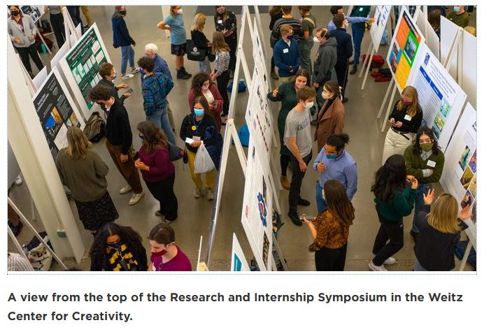

Carleton College News

## Population and Sample

**Research Question:** Is the percent of Carleton College graduates who have performed undergraduate research different than the percentage nationally ($\sim20.3\%$)?

**Dataset:** Survey of Carleton College graduates

Set up:

- **Population**: All Carleton graduates
- **Sample**: Survey respondents

## Hypothesis Testing (in words)

**Research Question:** Is the percent of Carleton College graduates who have performed undergraduate research different than the percentage nationally ($\sim20.3\%$)?

**Dataset:** Survey of Carleton College graduates

What are our null and alternative hypotheses (in words)?

- **Null hypothesis ($H_0$):** The percent of Carleton College graduates performing undergraduate research is the same (not statistically different) as the national average.
- **Alternative hypothesis ($H_a$):** The percent of Carleton College graduates performing undergraduate research is (statistically) different from the national average.

## Hypothesis Testing (population parameter)

**Research Question:** Is the percent of Carleton College graduates performing undergraduate research different than the national average ($\sim20.3\%$)?

**Dataset:** Survey of Carleton College graduates

What are our null and alternative hypotheses (in terms of the population parameter)?

- **Null hypothesis ($H_0$):** The percent of Carleton College graduates performing undergraduate research is the same (not statistically different) as the national average.
  - $H_0:$ $p = 20.3\%$
- **Alternative hypothesis ($H_a$):** The percent of Carleton College graduates performing undergraduate research is statistically different from the national average.
  - $H_a:$ $p \neq 20.3\%$

## Activity in Groups

**TikTok:** Do Carleton College students spend more than 2 hours on TikTok per day?

- Express the hypotheses for this question in both words and mathematical forms (using the correct notation).

**Friday Flowers:** The flower salespeople want to improve marketing and outreach. They want to know if more than a majority of students receive a flower during their time at Carleton.

- Express the hypotheses for this question in both words and mathematical forms (using the correct notation).

## TikTok Example

**Research Question:** Do Carleton College students spend more than 2 hours on TikTok per day?

What are our null and alternative hypotheses?

- **Null hypothesis ($H_0$):** The average time spent on TikTok by Carleton College students is 2 hours.
  - $H_0:$ $\mu = 2\text{ hours}$
- **Alternative hypothesis ($H_a$):** The average time spent on TikTok by Carleton College students is more than 2 hours.
  - $H_a:$ $\mu > 2\text{ hours}$

## Friday Flowers Example

**Research Question:** Do more than 50% of Carleton College students receive Friday Flowers while at Carleton?

What are our null and alternative hypotheses?

- **Null hypothesis ($H_0$):** The percent of students that receive Friday Flowers is 50%.
  - $H_0:$ $p = 50\%$
- **Alternative hypothesis ($H_a$):** The percent of students that receive Friday Flowers is more than 50%.
  - $H_a:$ $p > 50\%$

## Testing Differences

- We might also be interested in testing the **difference in means** or the **difference in proportions**

**Example**

- Students were given words to memorize, then randomly assigned to take either a 90 min nap, or a caffeine pill. 2.5 hours later, they were tested on their recall ability.
- Explanatory variable: sleep or caffeine
- Response variable: number of words recalled
- **Question:** Is sleep or caffeine better for memory?

Mednick, Cai, Kanady, and Drummond (2008). “Comparing the benefits of caffeine, naps and placebo on verbal, motor and perceptual memory,” *Behavioral Brain Research*, 193, 79-86.

## Sleep vs Caffeine

- Is sleep or caffeine better for memory? (Response: number of words recalled)
- Is this a difference in means or difference in proportions?
- The response variable (number of words recalled) is quantitative and the explanatory variable (sleep or caffeine) is categorical, so we are interested in a **difference in means**.

## Sleep vs Caffeine

- Let $\mu_S$ and $\mu_C$ be the mean number of words recalled after sleeping and after caffeine.
- Is there a difference in average word recall between sleep and caffeine?
- What are the null and alternative hypotheses?
1. $H_0: \mu_S \neq \mu_C$, $H_a: \mu_S = \mu_C$
2. $H_0: \mu_S = \mu_C$, $H_a: \mu_S \neq \mu_C$
3. $H_0: \mu_S = \mu_C$, $H_a: \mu_S > \mu_C$

b) The null hypotheses is “no difference,” or that the mean number of words recalled after sleeping and caffeine are equal. The alternative hypothesis is that the two means after both treatments are not equal.

## Testing Differences

- Note that the following two sets of hypotheses are equivalent, and can be used interchangeably:

$H_0: \mu_1 = \mu_2$, $H_a: \mu_1 \neq \mu_2$

$H_0: \mu_1 - \mu_2 = 0$, $H_a: \mu_1 - \mu_2 \neq 0$

# Statistical Tests vs CIs

## Hypothesis Testing vs Confidence Intervals

- Sometimes we can answer our question with a hypothesis test
  - Testing a claim
- Other times a confidence interval is more appropriate
  - Estimating a parameter or a difference in parameters

## Determine the best inference method:

**Hypothesis Test or Confidence Interval?** Give the appropriate notation for the test or confidence interval.

**Example 1**

What proportion of US adults support gun control?

- CI for $p$ (prop of US adults who support gun control)

**Example 2**

Does the proportion of US adults who support gun control differ between the Midwest and New England?

- $p_{MW}$ = prop of Midwesterners who support gun control
- $p_{NE}$ = prop of New Englanders who support gun control
- $H_0: p_{MW} = p_{NE}$
- $H_a: p_{MW} \neq p_{NE}$

## Determine the best inference method:

**Hypothesis Test or Confidence Interval?** Give the appropriate notation for the test or confidence interval.

**Example 3**

How much more do football players earn, on average, compared to soccer players in the US?

- “how much” means an estimate: confidence interval for $\mu_f - \mu_s$
- $\mu_f$= mean income (yearly) of US football players
- $\mu_s$= mean income (yearly) of US soccer players

**Example 4**

Is a higher rate of cricket chirping associated with higher summer night temps?

- Test a claim about an association:
- $H_0: \rho = 0$ or $\beta = 0$, $H_a: \rho > 0$ or $\beta >0$
- $\rho$ = correlation between temp and chirp rate
- $\beta$ = change in temp for a one unit increase in chirp rate

## Note on CI vs tests

Note that a CI or a test isn’t always **necessary/appropriate**. Can we answer the question with existing data? Are we asking about a population parameter?

Examples:

- What is the sample average word length?
- What is the proportion of red M&M’s in a given bag?
- What is the average number of shoes for this class?

## Evidence

**Statistical Evidence**

Let $\hat{p}$ denote the sample proportion of correct guesses.

- Which of the statistics below would give the **strongest evidence for ESP**?
1. $\hat{p}$ = 0
2. $\hat{p}$ = 1/5
3. $\hat{p}$ = 1/2
4. $\hat{p}$ = 3/4

3/4 is the highest, so provides the strongest evidence of ESP.

## Evidence

**Statistical Evidence**

Let $\hat{p}_{MW}$ denote sample proportion of Midwesterners who support gun control, and $\hat{p}_{NE}$ denote sample proportion for New Englanders.

- Which of the statistics below would give the **strongest evidence for a difference between Midwesterners and New Englanders in gun support**?
- This is evidence for $H_a$ ($p_{MW} \neq p_{NE}$)
1. $\hat{p}_{NE}$ = 0.1, $\hat{p}_{MW}$ = 0.15
2. $\hat{p}_{NE}$ = 0.1, $\hat{p}_{MW}$ = 0.05
3. $\hat{p}_{NE}$ = 0.1, $\hat{p}_{MW}$ = 0.2
3. gives the largest difference between Midwesterners and New Englanders, so it is the strongest evidence for $H_a$

## Next Class

Statistical Discernibility

Permutation Tests (determining p-values)